# HR_Analytics

```python
## Import All Library
import pandas as pd
import matplotlib.pyplot as plt
import numpy as np
import seaborn as sns
```

```python
##Import Data
```

```python
hr = pd.read_csv("datasets/HR_Analytics.csv")
hr.head(10)
```

|  | EmpID | Age | AgeGroup | Attrition | BusinessTravel | DailyRate | Department | DistanceFromHome | Education | EducationField | ... | RelationshipSatisfaction | StandardHours | StockOptionLevel | TotalWorkingYears | TrainingTimesLastYear | WorkLifeBalance | YearsAtCompany | YearsInCurrentRole | YearsSinceLastPromotion | YearsWithCurrManager |
| --- | --- | --- | --- | --- | --- | --- | --- | --- | --- | --- | --- | --- | --- | --- | --- | --- | --- | --- | --- | --- | --- |
| 0 | RM297 | 18 | 18-25 | Yes | Travel_Rarely | 230 | Research & Development | 3 | 3 | Life Sciences | ... | 3 | 80 | 0 | 0 | 2 | 3 | 0 | 0 | 0 | 0.0 |
| 1 | RM302 | 18 | 18-25 | No | Travel_Rarely | 812 | Sales | 10 | 3 | Medical | ... | 1 | 80 | 0 | 0 | 2 | 3 | 0 | 0 | 0 | 0.0 |
| 2 | RM458 | 18 | 18-25 | Yes | Travel_Frequently | 1306 | Sales | 5 | 3 | Marketing | ... | 4 | 80 | 0 | 0 | 3 | 3 | 0 | 0 | 0 | 0.0 |
| 3 | RM728 | 18 | 18-25 | No | Non-Travel | 287 | Research & Development | 5 | 2 | Life Sciences | ... | 4 | 80 | 0 | 0 | 2 | 3 | 0 | 0 | 0 | 0.0 |
| 4 | RM829 | 18 | 18-25 | Yes | Non-Travel | 247 | Research & Development | 8 | 1 | Medical | ... | 4 | 80 | 0 | 0 | 0 | 3 | 0 | 0 | 0 | 0.0 |
| 5 | RM973 | 18 | 18-25 | No | Non-Travel | 1124 | Research & Development | 1 | 3 | Life Sciences | ... | 3 | 80 | 0 | 0 | 5 | 4 | 0 | 0 | 0 | 0.0 |
| 6 | RM1154 | 18 | 18-25 | Yes | Travel_Frequently | 544 | Sales | 3 | 2 | Medical | ... | 3 | 80 | 0 | 0 | 2 | 4 | 0 | 0 | 0 | 0.0 |
| 7 | RM1312 | 18 | 18-25 | No | Non-Travel | 1431 | Research & Development | 14 | 3 | Medical | ... | 3 | 80 | 0 | 0 | 4 | 1 | 0 | 0 | 0 | 0.0 |
| 8 | RM128 | 19 | 18-25 | Yes | Travel_Rarely | 528 | Sales | 22 | 1 | Marketing | ... | 4 | 80 | 0 | 0 | 2 | 2 | 0 | 0 | 0 | 0.0 |
| 9 | RM150 | 19 | 18-25 | No | Travel_Rarely | 1181 | Research & Development | 3 | 1 | Medical | ... | 4 | 80 | 0 | 1 | 3 | 3 | 1 | 0 | 0 | 0.0 |

10 rows × 38 columns

```python
##Checked Data Type & Null
```

```python
hr.info()
```

```
<class 'pandas.core.frame.DataFrame'>
RangeIndex: 1480 entries, 0 to 1479
Data columns (total 38 columns):
 #   Column                    Non-Null Count  Dtype
---  ------                    --------------  -----
 0   EmpID                     1480 non-null   object
 1   Age                       1480 non-null   int64
 2   AgeGroup                  1480 non-null   object
 3   Attrition                 1480 non-null   object
 4   BusinessTravel            1480 non-null   object
 5   DailyRate                 1480 non-null   int64
 6   Department                1480 non-null   object
 7   DistanceFromHome          1480 non-null   int64
 8   Education                 1480 non-null   int64
 9   EducationField            1480 non-null   object
```

[output cut: 30 more lines]

```python
##Replaced Null Value With AVG in YearWithCurrManager Column
```

```python
hr['YearsWithCurrManager'] = hr['YearsWithCurrManager'].fillna(
    hr.groupby('YearsAtCompany')['YearsWithCurrManager'].transform('mean'))
```

```python
hr.isnull().sum()
```

```
EmpID                       0
Age                         0
AgeGroup                    0
Attrition                   0
BusinessTravel              0
DailyRate                   0
Department                  0
DistanceFromHome            0
Education                   0
EducationField              0
EmployeeCount               0
EmployeeNumber              0
EnvironmentSatisfaction     0
Gender                      0
HourlyRate                  0
JobInvolvement              0
JobLevel                    0
JobRole                     0
JobSatisfaction             0
MaritalStatus               0
MonthlyIncome               0
SalarySlab                  0
MonthlyRate                 0
NumCompaniesWorked          0
Over18                      0
OverTime                    0
PercentSalaryHike           0
PerformanceRating           0
RelationshipSatisfaction    0
StandardHours               0
StockOptionLevel            0
TotalWorkingYears           0
TrainingTimesLastYear       0
WorkLifeBalance             0
YearsAtCompany              0
YearsInCurrentRole          0
YearsSinceLastPromotion     0
YearsWithCurrManager        0
dtype: int64
```

```python
##Changes Data Type of YearWithCurrManager from Float to Int
```

```python
hr["YearsWithCurrManager"] = hr["YearsWithCurrManager"].astype("int")
```

```python
hr.info()
```

```
<class 'pandas.core.frame.DataFrame'>
RangeIndex: 1480 entries, 0 to 1479
Data columns (total 38 columns):
 #   Column                    Non-Null Count  Dtype
---  ------                    --------------  -----
 0   EmpID                     1480 non-null   object
 1   Age                       1480 non-null   int64
 2   AgeGroup                  1480 non-null   object
 3   Attrition                 1480 non-null   object
 4   BusinessTravel            1480 non-null   object
 5   DailyRate                 1480 non-null   int64
 6   Department                1480 non-null   object
 7   DistanceFromHome          1480 non-null   int64
 8   Education                 1480 non-null   int64
 9   EducationField            1480 non-null   object
```

[output cut: 30 more lines]

```python
##Checked Duplicate Values
```

```python
hr.duplicated(["EmpID"]).sum()
```

```
np.int64(10)
```

```python
##Removed Duplicates from the Data
```

```python
hr.drop_duplicates(['EmpID'],inplace=True)
hr
```

|  | EmpID | Age | AgeGroup | Attrition | BusinessTravel | DailyRate | Department | DistanceFromHome | Education | EducationField | ... | RelationshipSatisfaction | StandardHours | StockOptionLevel | TotalWorkingYears | TrainingTimesLastYear | WorkLifeBalance | YearsAtCompany | YearsInCurrentRole | YearsSinceLastPromotion | YearsWithCurrManager |
| --- | --- | --- | --- | --- | --- | --- | --- | --- | --- | --- | --- | --- | --- | --- | --- | --- | --- | --- | --- | --- | --- |
| 0 | RM297 | 18 | 18-25 | Yes | Travel_Rarely | 230 | Research & Development | 3 | 3 | Life Sciences | ... | 3 | 80 | 0 | 0 | 2 | 3 | 0 | 0 | 0 | 0 |
| 1 | RM302 | 18 | 18-25 | No | Travel_Rarely | 812 | Sales | 10 | 3 | Medical | ... | 1 | 80 | 0 | 0 | 2 | 3 | 0 | 0 | 0 | 0 |
| 2 | RM458 | 18 | 18-25 | Yes | Travel_Frequently | 1306 | Sales | 5 | 3 | Marketing | ... | 4 | 80 | 0 | 0 | 3 | 3 | 0 | 0 | 0 | 0 |
| 3 | RM728 | 18 | 18-25 | No | Non-Travel | 287 | Research & Development | 5 | 2 | Life Sciences | ... | 4 | 80 | 0 | 0 | 2 | 3 | 0 | 0 | 0 | 0 |
| 4 | RM829 | 18 | 18-25 | Yes | Non-Travel | 247 | Research & Development | 8 | 1 | Medical | ... | 4 | 80 | 0 | 0 | 0 | 3 | 0 | 0 | 0 | 0 |
| ... | ... | ... | ... | ... | ... | ... | ... | ... | ... | ... | ... | ... | ... | ... | ... | ... | ... | ... | ... | ... | ... |
| 1475 | RM412 | 60 | 55+ | No | Travel_Rarely | 422 | Research & Development | 7 | 3 | Life Sciences | ... | 4 | 80 | 0 | 33 | 5 | 1 | 29 | 8 | 11 | 10 |
| 1476 | RM428 | 60 | 55+ | No | Travel_Frequently | 1499 | Sales | 28 | 3 | Marketing | ... | 4 | 80 | 0 | 22 | 5 | 4 | 18 | 13 | 13 | 11 |
| 1477 | RM537 | 60 | 55+ | No | Travel_Rarely | 1179 | Sales | 16 | 4 | Marketing | ... | 4 | 80 | 0 | 10 | 1 | 3 | 2 | 2 | 2 | 2 |
| 1478 | RM880 | 60 | 55+ | No | Travel_Rarely | 696 | Sales | 7 | 4 | Marketing | ... | 2 | 80 | 1 | 12 | 3 | 3 | 11 | 7 | 1 | 9 |
| 1479 | RM1210 | 60 | 55+ | No | Travel_Rarely | 370 | Research & Development | 1 | 4 | Medical | ... | 3 | 80 | 1 | 19 | 2 | 4 | 1 | 0 | 0 | 0 |

1470 rows × 38 columns

```python
hr.duplicated().sum()
```

```
np.int64(0)
```

```python
##Data Analysis
```

```python
ar = hr.groupby('Attrition').agg(Count=('Attrition', 'count'))
ar
```

| Attrition | Count |
| --- | --- |
| No | 1233 |
| Yes | 237 |

## Overall Attrition

Total Employees: 1470

Attrition = Yes: 237 → ~16.1%

Attrition = No: 1233 → ~83.9%

So overall attrition in the company is about 16%.

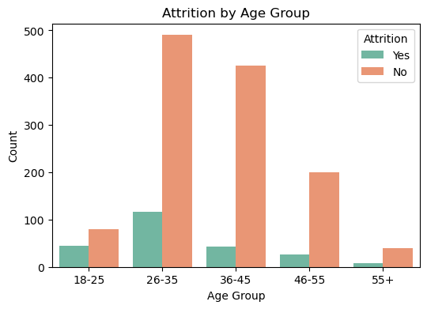

```python
## Agegrp Wise Attrition

plt.figure(figsize=(6,4))
sns.countplot(hr, x='AgeGroup', hue="Attrition", palette='Set2')
plt.title('Attrition by Age Group')
plt.xlabel('Age Group')
plt.ylabel('Count')
plt.show()
```

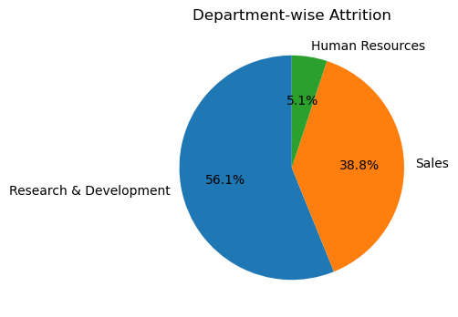

```python
# Filter only employees who left
attrition_data = hr[hr['Attrition'] == 'Yes']

# Count attrition per department
dept_counts = attrition_data['Department'].value_counts()

# Plot pie chart
plt.figure(figsize=(6,4))
plt.pie(dept_counts, labels=dept_counts.index, autopct='%1.1f%%', startangle=90)
plt.title("Department-wise Attrition")
plt.show()
```

## Department Wise Attrition

Research & Development – 56.1%

This department contributes the highest attrition.

👉 More than half of total employee exits are from R&D.

Insight: Possible reasons could be workload pressure, skill-market demand, role stress, or limited growth opportunities.

Business Risk: High impact area – losing technical talent affects productivity & innovation.

Sales – 38.8%

Second highest attrition contributor.

👉 Almost 2 out of every 5 employees leaving are from Sales.

Insight: Could indicate performance pressure, targets, incentives, or job stress.

Business Risk: Revenue and customer relationships may be impacted.

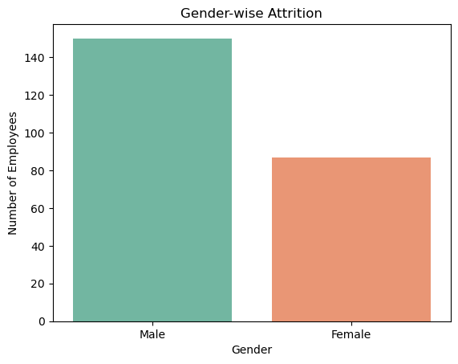

```python
# Filter only employees who left
attrition_data = hr[hr['Attrition'] == 'Yes']

# Plot gender-wise attrition
sns.countplot(x='Gender', data=attrition_data,palette="Set2")
plt.title("Gender-wise Attrition")
plt.ylabel("Number of Employees")
plt.show()
```

## Gender Wise Attrition

Nearly 63% of attrition comes from male employees, which is significantly higher than females.

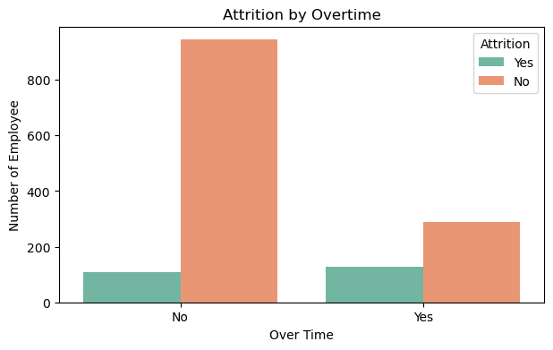

```python
plt.figure(figsize=(7,4))
plt.title('Attrition by Overtime')
plt.xlabel('Over Time')
plt.ylabel('Number of Employee')
sns.countplot(hr,x='OverTime',hue='Attrition',palette="Set2")
plt.show()
```

## Attrition by Overtime

Employees with No Overtime

Attrition (Yes) ≈ 110

Retained (No) ≈ 950

Total ≈ 1060 employees

👉 Attrition Rate ≈ 10%

Most employees who don’t work overtime stay in the company

Employees with Overtime = Yes

Attrition (Yes) ≈ 130

Retained (No) ≈ 290

Total ≈ 420 employees

👉 Attrition Rate ≈ 31%

⚠️ Nearly 1 in 3 employees who work overtime leave the company

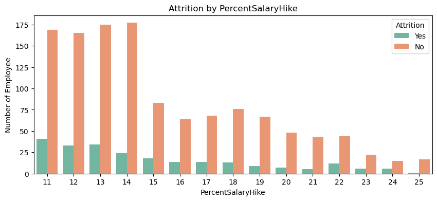

```python
plt.figure(figsize=(10,4))
plt.title('Attrition by PercentSalaryHike')
plt.xlabel('PercentSalaryHike')
plt.ylabel('Number of Employee')
sns.countplot(hr,x='PercentSalaryHike',hue='Attrition',palette="Set2")
plt.show()
```

## Attrition by PercentSalaryHike

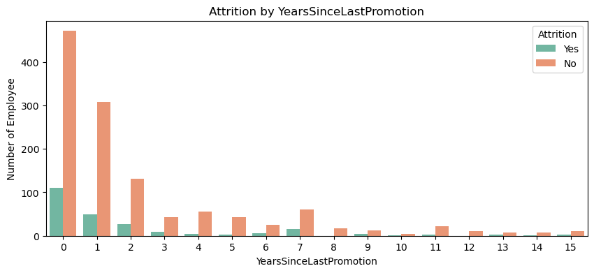

```python
plt.figure(figsize=(10,4))
plt.title('Attrition by YearsSinceLastPromotion')
plt.xlabel('YearsSinceLastPromotion')
plt.ylabel('Number of Employee')
sns.countplot(hr,x='YearsSinceLastPromotion',hue='Attrition',palette="Set2")
plt.show()
```

## YearsSinceLastPromotion

Early exits (0–1 years) suggest non-financial factors driving attrition

Long-term stagnation (5+ years) shows slow but persistent attrition

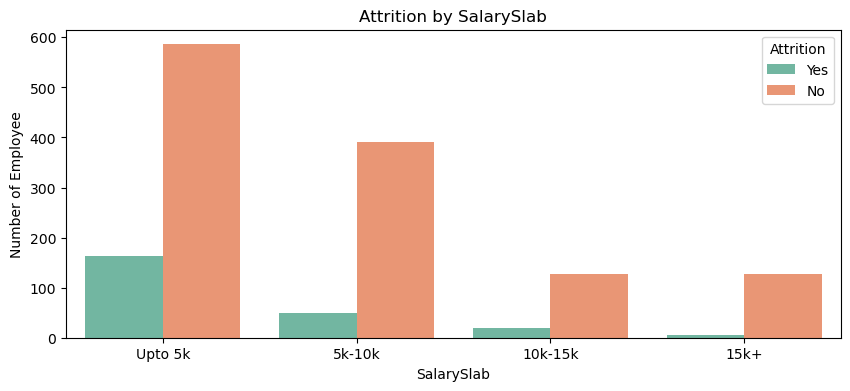

```python
plt.figure(figsize=(10,4))
plt.title('Attrition by SalarySlab')
plt.xlabel('SalarySlab')
plt.ylabel('Number of Employee')
sns.countplot(hr,x='SalarySlab',hue='Attrition',palette="Set2")
plt.show()
```

## Attrition by SalarySlab

The "Upto 5k" Slab This group is the primary driver of turnover for the company.

Volume: This slab has the highest number of both total employees and leavers.

Attrition Rate: Approximately 22% (163 leavers vs. ~580 stayers).

Insight: Employees in the lowest pay bracket are significantly more likely to leave, possibly due to seeking better entry-level opportunities elsewhere or financial dissatisfaction.